# Human and Economic Costs of Severe Weather in the USA, 1996-2011

DJWilliamson

28 December 2015

# Synopsis

This study has examined the human and economic costs of severe weather events in the US over the period 1996-2011 using data from the NOAA. Data were excluded from offshore sites and earlier periods where the data were incomplete. The economic costs of damage to property and crops were predominantly attributable to wind and water (floods, thunderstorms, hurricanes, tornadoes), but hail and drought were also significant contributors. There was a spike in property damage in 2005 attributable to Hurricane Katrina. Excessive heat, tornadoes, thunderstorms and flooding contributed most to the human costs of severe weather.

# Background

# Data Processing

### Data source

The data are available at:  
https://d396qusza40orc.cloudfront.net/repdata%2Fdata%2FStormData.csv.bz2

### Code Book

The dataset is stored in a comma-separated-value (csv) file. There are a total of 902297 observations.

Further information about variables included in this dataset are available:  
* National Weather Service Storm Data Documentation [stormDatadocs](https://d396qusza40orc.cloudfront.net/repdata%2Fpeer2_doc%2Fpd01016005curr.pdf)  
* National Climatic Data Center Storm Events FAQ [FAQ](https://d396qusza40orc.cloudfront.net/repdata%2Fpeer2_doc%2FNCDC%20Storm%20Events-FAQ%20Page.pdf)  
* Storm Data Export Format [exportFormat](http://www1.ncdc.noaa.gov/pub/data/swdi/stormevents/csvfiles/Storm-Data-Export-Format.docx)

Additional code, figures from exploratory data analysis and relevant files are available in my GitHub repository: https://github.com/DJamesWilliamson/Reproducible-Research-PA2

### Structure

The steps in the data processing are:  
1. Downloading and unzipping the csv file (which may be omitted)  
2. Reading the file into R  
3. Renaming, selecting and adding variables  
4. Restricting the analysis to data from 1996 (see above)  
5. Examining and replacing the multipliers for cost calculations  
6. Restricting the analysis to events with a human or economic impact (2-stage)  
7. Standardising the event codes against the official classification  
8. Restricting the geographical areas for the analysis to 51 states  
9. Checking and where appropriate adjusting outliers

```r
# Create a folder for the data in the current directory and set it as the working directory (commented out as generally inadvisable to use setwd() in code):
# if(!file.exists("Storm_Data")) dir.create("Storm_Data")
# setwd("./Storm_Data")
```

Load the packages required for the analysis (installing them if necessary):

```r
library(R.utils)
library(dplyr)
library(stringr)
library(data.table)
```

```r
library(ggplot2)
library(lattice)
library(xtable)
```

================================================================================

Download and unzip the csv file:

```r
# dataset_url <- "https://d396qusza40orc.cloudfront.net/repdata%2Fdata%2FStormData.csv.bz2"
# fileDest <- sprintf("storm_%s.bz2", format(Sys.time(),"%Y_%m_%d_%H_%M_%S"))
# download.file(dataset_url, fileDest, mode = "wb", method = "libcurl")
# bunzip2(filename = fileDest, destname = "storm.csv")
```

The date of download is included in the name of the zip file for future reference.

Read in the data and check:

```r
data <- tbl_df(fread("repdata_data_StormData.csv",
                     sep = ",",
                     # nrows = 100,
                     header = TRUE,
                     na.strings = "",
                     stringsAsFactors = FALSE,
                     select = c(1, 2, 5, 7, 8, 23:30, 37),
                     data.table = FALSE,
                     verbose = FALSE))
```

```
##
Read 78.6% of 967216 rows
Read 902297 rows and 14 (of 37) columns from 0.523 GB file in 00:00:03
```

```r
# str(data)
nRecords1 <- nrow(data)
```

At this stage there are 902297 records.

Rename and reorder variables; capitalise and trim EVTYPE;remove original file:

```r
storms <- data %>%
        rename(stateCode = STATE__,
               beginDate = BGN_DATE,
               countyCode = COUNTY,
               state = STATE,
               eventType = EVTYPE,
               fatalities = FATALITIES,
               injuries = INJURIES,
               propDamage = PROPDMG,
               propDamageExp = PROPDMGEXP,
               cropDamage = CROPDMG,
               cropDamageExp = CROPDMGEXP,
               wfo = WFO,
               stateOffice = STATEOFFIC,
               refNum = REFNUM) %>%
        select(refNum, beginDate, stateCode, state, countyCode, wfo, stateOffice,
               eventType,
               fatalities, injuries,
               propDamage, propDamageExp,
               cropDamage, cropDamageExp) %>%
        mutate(eventType = toupper(eventType)) %>%
        mutate(eventType = str_trim(eventType, "both"))
rm(data)
```

Change beginDate to class Date and filter records since 1996 (full data available):

```r
storms$beginDate <- str_replace(storms$beginDate, " 0:00:00", "")
storms$beginDate <- as.Date(storms$beginDate, "%m/%d/%Y")
storms <- storms %>%
        filter(beginDate >= "1996-01-01") %>%
        arrange(beginDate)
nRecords2 <- nrow(storms)
```

At this stage there are 653530 records.

Update critical variables (note one inappropriate propDamageExp, but no impact):

```r
table(storms$propDamageExp)
```

```
##
##      0      B      K      M
##      1     32 369938   7374
```

```r
table(storms$cropDamageExp)
```

```
##
##      B      K      M
##      4 278686   1771
```

```r
storms %>% select(propDamageExp, fatalities, injuries, propDamage, cropDamage) %>%
        group_by(propDamageExp) %>%
        summarise(n = n(), people = sum(fatalities + injuries),
                  damage = sum(propDamage + cropDamage)) %>%
        arrange(desc(n))
```

```
## Source: local data frame [5 x 4]
##
##   propDamageExp      n people     damage
##           (chr)  (int)  (dbl)      (dbl)
## 1             K 369938  19040 8379626.95
## 2            NA 276185  17582  204723.66
## 3             M   7374  26812  256915.76
## 4             B     32   3273    1828.06
## 5             0      1      0       0.00
```

```r
storms$propDamageExp <- replace(storms$propDamageExp,
                                which(storms$propDamageExp == "0"), "NA")
storms$propDamageExp <- replace(storms$propDamageExp,
                                which(storms$propDamageExp == "K"), "1000")
storms$propDamageExp <- replace(storms$propDamageExp,
                                which(storms$propDamageExp == "M"), "1000000")
storms$propDamageExp <- replace(storms$propDamageExp,
                                which(storms$propDamageExp == "B"), "1000000000")
storms$propDamageExp <- as.numeric(storms$propDamageExp)
storms$cropDamageExp <- replace(storms$cropDamageExp,
                                which(storms$cropDamageExp == "K"), "1000")
storms$cropDamageExp <- replace(storms$cropDamageExp,
                                which(storms$cropDamageExp == "M"), "1000000")
storms$cropDamageExp <- replace(storms$cropDamageExp,
                                which(storms$cropDamageExp == "B"), "1000000000")
storms$cropDamageExp <- as.numeric(storms$cropDamageExp)
```

Identify/exclude eventTypes where there is no damage to people, property or crops:

```r
noDamageTable <- storms %>% select(eventType, fatalities, injuries,
                                   propDamage, propDamageExp,
                                   cropDamage, cropDamageExp) %>%
        group_by(eventType) %>%
        summarise(n = n(),
                  people = as.numeric(sum(fatalities + injuries, na.rm = TRUE)),
                  damage = as.numeric(sum(propDamage + cropDamage, na.rm = TRUE))) %>%
        arrange(desc(n)) %>%
        filter(people == 0 & damage == 0)
noDamageEvents <- noDamageTable$eventType
storms <- storms %>%
        filter(!(eventType %in% noDamageEvents))
nRecords3 <- nrow(storms)
```

At this stage there are 652447 records.

Correct event types to assist matching and standardise against official codes:

```r
storms$eventType <- gsub("TSTM", "THUNDERSTORM", storms$eventType)
storms$eventType <- gsub("NON-THUNDERSTORM",  "STRONG", storms$eventType)
storms$eventType <- gsub("NON THUNDERSTORM",  "STRONG", storms$eventType)
storms$eventType <- gsub("CSTL",  "COASTAL", storms$eventType)
storms$eventType <- gsub("  ",  " ", storms$eventType)

event_types_standard <- read.table("event_types.csv",
                                header = FALSE,
                                sep = ",",
                                col.names = c("stdEvType", "designator",
                                              "keyTerm1", "keyTerm2",
                                              "keyTerm3", "keyTerm4"))
event_types_standard <- event_types_standard %>%
        mutate(stdEvType = toupper(stdEvType),
               keyTerm1 = toupper(keyTerm1),
               keyTerm2 = toupper(keyTerm2),
               keyTerm3 = toupper(keyTerm3),
               keyTerm4 = toupper(keyTerm4))

stdEvType <-event_types_standard$stdEvType
keyTerm1 <- event_types_standard$keyTerm1
keyTerm2 <- event_types_standard$keyTerm2
keyTerm3 <- event_types_standard$keyTerm3
keyTerm4 <- event_types_standard$keyTerm4

events_to_match <- storms %>%
        mutate(eventTypeMatch = eventType %in% stdEvType) %>%
        filter(eventTypeMatch == "FALSE") %>%
        select(eventType)
events_to_match <- sort(unique(events_to_match$eventType))
nEventsToMatch <- length(events_to_match)
```

Note that the event_types.csv file is available in the GitHub repository. This provides the standard classification of event types (see reference above) and a number of key terms based on exploratory analysis of the data which are useful in allocating the non-standard event types in the database. There are 131 non-standard events to be matched.

Function to map events_to_match (x) against keyTerms (y) and stdEvType (z, default):

```r
matchingGrep <-  function(x,y,z = stdEvType) {
        output <- list(length(y))
        for(i in 1:length(y)) {
                output[[i]] <- x[grep(y[i], x)]
        }
        eventType <- as.vector(unlist(output))
        n <- as.vector(unlist(sapply(output, length)))
        match <- rep(z, times = n)
        replacements <- tbl_df(as.data.frame(cbind(eventType, match)))
        replacements <- replacements %>%
                filter(!duplicated(eventType))
        return(replacements)
}
```

Use matchingGrep and the keyTerms in the event_types.csv file to standardise events:

```r
replacements1 <- matchingGrep(events_to_match, keyTerm1)
remove <- which(events_to_match %in% replacements1$eventType)
events_to_match <- events_to_match[-remove]

replacements2 <- matchingGrep(events_to_match, keyTerm2)
remove <- which(events_to_match %in% replacements2$eventType)
events_to_match <- events_to_match[-remove]

replacements3 <- matchingGrep(events_to_match, keyTerm3)
remove <- which(events_to_match %in% replacements3$eventType)
events_to_match <- events_to_match[-remove]

replacements4 <- matchingGrep(events_to_match, keyTerm4)
remove <- which(events_to_match %in% replacements4$eventType)
events_to_match <- events_to_match[-remove]

replacements5 <- cbind(eventType = events_to_match,
                       match = rep("OTHER", length(events_to_match)))

# nonStandardEvents <- rbind(replacements1, replacements2, replacements3,
#                             replacements4, replacements5)
# write.csv(nonStandardEvents, file = "nonStandard_events.csv")

stdEvents <- event_types_standard %>%
                        select(eventType = stdEvType, match = keyTerm1)
matchingTable <- rbind(replacements1, replacements2, replacements3,
                                replacements4, replacements5,
                                stdEvents)
storms <- left_join(storms, matchingTable, by = "eventType")
nreplacements <- nrow(replacements5)
```

The file nonStandardEvents.csv is available in the GitHub repository. This documents the non-standard event types in the database and their match in the standard classification. There were 18 unmatched types which were allocated to “OTHER”. These mainly related to mud, rock or land slides.

Review the variables and exclude all but 51 states:

```r
# review the variables
uniqueValues <- sapply(storms, unique)
sapply(uniqueValues, length)
```

```
##        refNum     beginDate     stateCode         state    countyCode
##        652447          5800            69            70           553
##           wfo   stateOffice     eventType    fatalities      injuries
##           125           250           176            37           133
##    propDamage propDamageExp    cropDamage cropDamageExp         match
##          1381             4           415             4            47
```

```r
# indicates a problem with the number of states

# read in US state code data
fipsCodes <- read.csv("US State FIPS codes.csv")
includedStates <- which(storms$stateCode %in% fipsCodes$FIPS.Code)
excludedStateCodes <- sort(unique(storms$stateCode[-includedStates]))
excludedEntries <- filter(storms, stateCode %in% excludedStateCodes)
excludedStates <- sort(unique(excludedEntries$state))
#select data
stormsData <- storms %>%
                mutate(propDamageCost = propDamage * propDamageExp,
                        cropDamageCost = cropDamage * cropDamageExp) %>%
                rename(event = match,
                       FIPS.code = stateCode) %>%
                filter(!(FIPS.code %in% excludedStateCodes)) %>%
                select(refNum, beginDate, state, event,
                       fatalities, injuries,
                       propDamageCost, cropDamageCost) %>%
                mutate(state = as.factor(state))
nRecords4 <- nrow(stormsData)
```

At this stage there are 634123 records.

The US State FIPS codes.csv file is available in the GitHub repository. There were more states than expected and some of the additional areas were neither in the extended FIPS codes (protectorates) or supplemental maritime codes.

Further restrict the analysis to entries where there are effects on people, property or crops:

```r
stormsData <- stormsData %>%
                filter(fatalities > 0 | injuries > 0 |
                               propDamageCost > 0 | cropDamageCost)
nRecords5 <- nrow(stormsData)
```

At this stage there are 200137 records.

Check for outliers, adjust if appropriate, remove source file, and select data:

```r
Mydotplot <- function(DataSelected){
        P <- dotplot(as.matrix(as.matrix(DataSelected)),
                     groups = FALSE,
                     strip = FALSE,
                     # strip = strip.custom(bg = 'white',
                     # par.strip.text = list(cex = 1.2)),
                     scales = list(x = list(relation = "free", draw = TRUE),
                                   y = list(relation = "free", draw = FALSE)),
                     col=1, cex  = 0.5, pch = 16,
                     xlab = list(label = "Cost($)", cex = 1.5),
                     ylab = list(label = "Order of data", cex = 1.5),
                     main = list(label = "Cleveland Dotplot", cex = 1.75))
        print(P)
}

# png(filename = "EDA_propDamageCost.png", width = 600, height = 480)
# par(mfrow = c(1,1))
# Mydotplot(stormsData$propDamageCost)
# dev.off()
# par(mfrow = c(1, 1))

# outlier identified and changed (million, not billion)
stormsData[which(stormsData$propDamageCost > 1.0e+11), ]
```

```
## Source: local data frame [1 x 8]
##
##   refNum  beginDate  state  event fatalities injuries propDamageCost
##    (dbl)     (date) (fctr) (fctr)      (dbl)    (dbl)          (dbl)
## 1 605943 2006-01-01     CA  FLOOD          0        0       1.15e+11
## Variables not shown: cropDamageCost (dbl)
```

```r
outlier <- storms[which(storms$refNum == 605943), ]
outlier[ c(11:16)]
```

```
## Source: local data frame [1 x 6]
##
##   propDamage propDamageExp cropDamage cropDamageExp  match     NA
##        (dbl)         (dbl)      (dbl)         (dbl) (fctr) (NULL)
## 1        115         1e+09       32.5         1e+06  FLOOD   NULL
```

```r
stormsData[which(stormsData$refNum == 605943), 7] <- 1.15e+8

# potential outlier identified as Hurricane Katrina (see below)
stormsData[which(stormsData$propDamageCost > 2.0e+10), ]
```

```
## Source: local data frame [1 x 8]
##
##   refNum  beginDate  state            event fatalities injuries
##    (dbl)     (date) (fctr)           (fctr)      (dbl)    (dbl)
## 1 577616 2005-08-29     LA STORM SURGE/TIDE          0        0
## Variables not shown: propDamageCost (dbl), cropDamageCost (dbl)
```

```r
outlier <- storms[which(storms$refNum == 577616), ]
outlier[ c(11:14)]
```

```
## Source: local data frame [1 x 4]
##
##   propDamage propDamageExp cropDamage cropDamageExp
##        (dbl)         (dbl)      (dbl)         (dbl)
## 1       31.3         1e+09          0            NA
```

```r
# png(filename = "EDA_cropDamageCost.png", width = 600, height = 480)
# par(mfrow = c(1,1))
# Mydotplot(stormsData$cropDamageCost)
# dev.off()
# par(mfrow = c(1, 1))

# potential outlier identified as Hurricane Katrina (unchanged)
stormsData[which(stormsData$cropDamageCost > 1.5e+9), ]
```

```
## Source: local data frame [1 x 8]
##
##   refNum  beginDate  state               event fatalities injuries
##    (dbl)     (date) (fctr)              (fctr)      (dbl)    (dbl)
## 1 581537 2005-08-29     MS HURRICANE (TYPHOON)         15      104
## Variables not shown: propDamageCost (dbl), cropDamageCost (dbl)
```

```r
outlier <- storms[which(storms$refNum == 577616), ]
outlier[ c(11:14)]
```

```
## Source: local data frame [1 x 4]
##
##   propDamage propDamageExp cropDamage cropDamageExp
##        (dbl)         (dbl)      (dbl)         (dbl)
## 1       31.3         1e+09          0            NA
```

```r
rm(storms)

stormsData$date = as.POSIXlt(stormsData$beginDate)
stormsData$year = stormsData$date$year + 1900

stormsData <- stormsData %>%
                select(refNum, beginDate, year, state, event,
                        fatalities, injuries,
                        propDamageCost, cropDamageCost)
```

# Results

### Time Series

The human cost of storm events has been evaluated in terms of “fatalities” and “injuries”. Figure 1 (2 panels) shows the totals attributed per annum to severe weather events in the US (51 states) over the period 1996-2011.

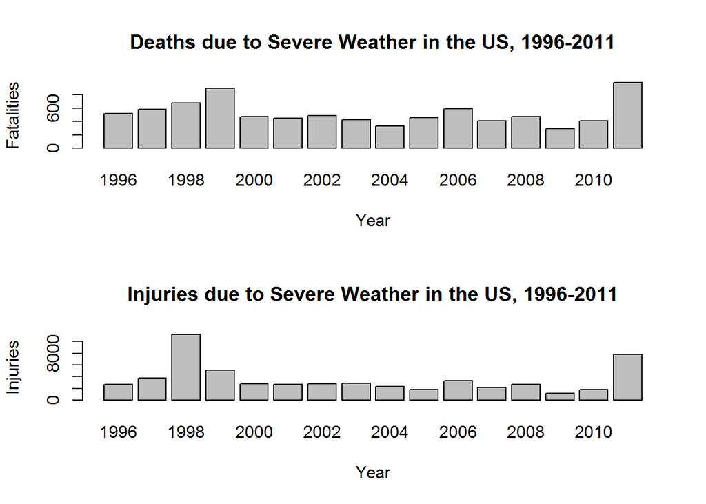

```r
annualHumanData <- group_by(stormsData, year) %>%
                summarise(Fatalities = sum(fatalities, na.rm = TRUE),
                                Injuries = sum(injuries, na.rm = TRUE))
par(mfrow = c(2,1))
barplot(height = annualHumanData$Fatalities, names.arg = annualHumanData$year,
        main = "Deaths due to Severe Weather in the US, 1996-2011",
        xlab = "Year",
        ylab = "Fatalities")
barplot(height = annualHumanData$Injuries, names.arg = annualHumanData$year,
        main = "Injuries due to Severe Weather in the US, 1996-2011",
        xlab = "Year",
        ylab = "Injuries")
```

```r
par(mfrow = c(1,1))
```

The economic cost of storm events has been evaluated in terms of damage to property and crops measured in billions of dollars. Figure 2 (2 panels) shows the totals attributed to storm events in the US (51 states) over the period 1996-2011. No adjustment has been made for inflation.

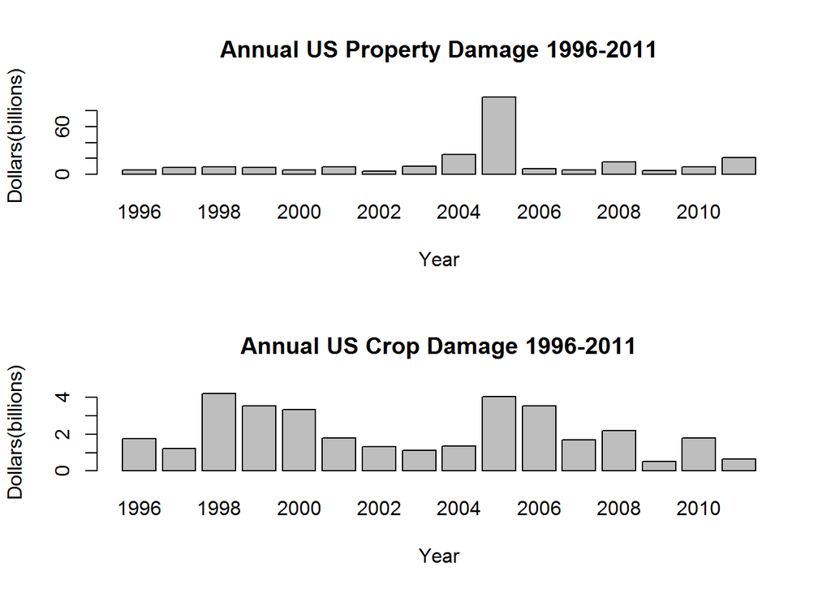

```r
annualEconomicData <- group_by(stormsData, year) %>%
                summarise(PropertyDamage = sum(propDamageCost/1.0e+9, na.rm = TRUE),
                                CropDamage = sum(cropDamageCost/1.0e+9, na.rm = TRUE))
par(mfrow = c(2,1))
barplot(height = annualEconomicData$PropertyDamage, names.arg = annualEconomicData$year,
        main = "Annual US Property Damage 1996-2011",
        xlab = "Year",
        ylab = "Dollars(billions)")
barplot(height = annualEconomicData$CropDamage, names.arg = annualEconomicData$year,
        main = "Annual US Crop Damage 1996-2011",
        xlab = "Year",
        ylab = "Dollars(billions)")
```

```r
par(mfrow = c(1,1))
```

The data show a marked increase in the estimated value of property damage in 2005 associated with Hurricane Katrina.

### Contributions of different events to human and economic costs

In considering which types of storm event have contributed most to human or economic costs I have only used the ‘official’ classifications of event type, although further analysis might permit similar event types to be grouped together. The following table shows the number of fatalities and injuries attributable to individual storm events over the period 1996-2011. Only the top 20 events are shown (by total fatalities).

```r
annualHumanData_byEvent <- group_by(stormsData, event) %>%
        summarise(Fatalities = sum(fatalities, na.rm = TRUE),
                  Injuries = sum(injuries, na.rm = TRUE)) %>%
        arrange(desc(Fatalities))
humanImpact <- annualHumanData_byEvent %>%
        filter(Fatalities >= 70) %>%
        rename(Event = event)
tab <- xtable(humanImpact, digits = c(0, 0, 0, 0))
print(tab, type="html")
```

|  | Event | Fatalities | Injuries |
| --- | --- | --- | --- |
| 1 | EXCESSIVE HEAT | 1797 | 6391 |
| 2 | TORNADO | 1511 | 20667 |
| 3 | FLASH FLOOD | 848 | 1666 |
| 4 | LIGHTNING | 642 | 4135 |
| 5 | RIP CURRENT | 488 | 445 |
| 6 | FLOOD | 441 | 6836 |
| 7 | THUNDERSTORM WIND | 374 | 5026 |
| 8 | HIGH WIND | 276 | 1188 |
| 9 | COLD/WIND CHILL | 241 | 103 |
| 10 | HEAT | 239 | 1311 |
| 11 | AVALANCHE | 223 | 156 |
| 12 | WINTER STORM | 191 | 1292 |
| 13 | HEAVY SNOW | 134 | 755 |
| 14 | EXTREME COLD/WIND CHILL | 125 | 24 |
| 15 | HIGH SURF | 115 | 217 |
| 16 | STRONG WIND | 110 | 297 |
| 17 | HURRICANE (TYPHOON) | 103 | 968 |
| 18 | WILDFIRE | 87 | 1457 |
| 19 | ICE STORM | 86 | 340 |
| 20 | BLIZZARD | 70 | 385 |

The following table shows the costs (in billions of dollars) of property and crop damage attributable to individual severe weather events. Only the top 20 events are shown (by total damage).

```r
annualEconomicData_byEvent <- group_by(stormsData, event) %>%
                summarise(PropertyDamage = sum(propDamageCost/1.0e+9, na.rm = TRUE),
                  CropDamage = sum(cropDamageCost/1.0e+9, na.rm = TRUE),
                  TotalDamage = PropertyDamage + CropDamage) %>%
        arrange(desc(PropertyDamage + CropDamage))
economicImpact <- annualEconomicData_byEvent %>%
                filter(TotalDamage >= 0.5) %>%
                rename(Event = event, Property = PropertyDamage,
                       Crops = CropDamage,  Total = TotalDamage)
tab <- xtable(economicImpact, digits = c(0, 0, 2, 2, 2))
print(tab, type="html")
```

|  | Event | Property | Crops | Total |
| --- | --- | --- | --- | --- |
| 1 | HURRICANE (TYPHOON) | 78.94 | 4.79 | 83.74 |
| 2 | STORM SURGE/TIDE | 47.84 | 0.00 | 47.84 |
| 3 | FLOOD | 29.13 | 4.97 | 34.09 |
| 4 | TORNADO | 24.62 | 0.28 | 24.90 |
| 5 | HAIL | 14.64 | 2.56 | 17.20 |
| 6 | FLASH FLOOD | 14.97 | 1.32 | 16.29 |
| 7 | DROUGHT | 1.04 | 13.37 | 14.41 |
| 8 | THUNDERSTORM WIND | 7.85 | 0.95 | 8.80 |
| 9 | WILDFIRE | 7.75 | 0.40 | 8.15 |
| 10 | TROPICAL STORM | 7.54 | 0.57 | 8.12 |
| 11 | HIGH WIND | 5.25 | 0.65 | 5.90 |
| 12 | ICE STORM | 3.64 | 0.02 | 3.66 |
| 13 | WINTER STORM | 1.53 | 0.01 | 1.54 |
| 14 | FROST/FREEZE | 0.02 | 1.37 | 1.39 |
| 15 | COLD/WIND CHILL | 0.02 | 1.34 | 1.36 |
| 16 | HEAVY RAIN | 0.60 | 0.74 | 1.34 |
| 17 | LIGHTNING | 0.74 | 0.01 | 0.75 |
| 18 | HEAVY SNOW | 0.64 | 0.07 | 0.71 |
| 19 | BLIZZARD | 0.53 | 0.01 | 0.53 |
| 20 | EXCESSIVE HEAT | 0.01 | 0.49 | 0.50 |

### Conclusion

Excessive heat, tornadoes, thunderstorms and flooding contributed most to the human costs of severe weather. Lightning killed 642 people and 488 were killed in rip currents. Wind and water (floods, thunderstorms, hurricanes, tornadoes) were responsible for most damage to property and crops, but hail and drought were also significant contributors.

## #

```r
# On completion, reset current working directory to initial wd (optional):
# setwd("../")
```